# Week 10 Teacher Demo: Exploring DHS data with {ggplot2}

Introduction to the {haven} package and ggplot themes

GRAPH Courses Team

2024-03-12

# Demographic and Health Survey (DHS) data

The Demographic and Health Surveys (DHS) are a series of standardized surveys conducted periodically in developing countries that collect data on various aspects of population, health, and nutrition. You will be using DHS data for the final project of this course, so this is a chance to practice working with this type of data.

## Nigeria Women’s Individual Recode, 2018

Several DHS datasets (called recodes) are made available from each survey. The *individual recode (IR)* dataset contains individual-level data on women aged 15 to 49 in the surveyed households. You will be using an women’s IR dataset for this workshop and for your individual final project.

Today we will be looking at women’s individual recode (IR) data from **Nigeria (2018)**. Key findings from this data can be found in this [report](https://drive.google.com/file/d/10pp9O9EJZvideynYyANqJtBCsN_vNQjs/view).

# Importing data with `{haven}` functions

DHS data comes in the form of a **.DTA file** (STATA format). To import the DHS dataset from the .DTA format into R, you will need the `read_dta()` function from the `{haven}` package.

Let’s start by loading in the needed packages.

```r
# Load packages
pacman::p_load(
  janitor, # data analysis utilities
  here, # force rmds to use the project folder as working directory
  haven, # for reading in stata files
  tidyverse # for everything!
  )
```

DHS files can be quite large – the original Nigeria 2018 data has over 40,000 rows and 5,000 columns. When datasets are that large, you need to avoid importing the entire dataset at once, as this may take unreasonably long to run and may cause R to freeze.

Instead, you can first select which variables you want to analyze and then import only those columns from the .dta file. This is not how we usually do it, but in this case we have a good reason.

## Importing only selected variables with `col_select`

Before importing the data, we must select which columns to include. If you look in your “data” folder of this workshop, you will see a file named NGIR7BFL_mini.DTA, which contains the IR data we want to use. Consult the data dictionary (**NGIR7BFL_data_dictionary.pdf**) in the “data” folder to choose variables based on their descriptions.

Below I use the **`col_select`** argument of **`read_dta()`** to specify which columns to import. For this demo, we will select basic demographic variables (age, location, education, etc.) and a few additional variables related to fertility and reproductive timing among women in Nigeria.

**IMPORTANT**: The data dictionary lists column names in all caps, but they are lowercase in the actual file. Remember to change letters to *lowercase*.

```r
# Reading in the .dta file
ir_raw <-
  haven::read_dta(here("data/NGIR7BFL_mini.DTA"),

                  # Provide a vector of column names
                  col_select = c(
                    # Basic information
                    v006, v007, v009, v010, v012, v013,
                    v024, v025, v106, v130, v190,
                    # Fertility and reproductive timing
                    v201, v212, v213, v511, v531))
```

**Note** - for this workshop, we created a “mini” version of the Nigeria dataset that has only the first 1000 rows, but in your actual final project you will be expected to work with all rows in the DTA file.

```r
# Look at a preview of the raw data frame
head(ir_raw)
```

```
## # A tibble: 6 × 16
##    v006  v007  v009  v010  v012 v013     v024    v025    v106    v130    v190
##   <dbl> <dbl> <dbl> <dbl> <dbl> <dbl+lb> <dbl+l> <dbl+l> <dbl+l> <dbl+l> <dbl+l>
## 1     9  2018     3  1978    40 6 [40-4… 1 [nor… 1 [urb… 3 [hig… 2 [oth… 5 [ric…
## 2     9  2018     6  2002    16 1 [15-1… 1 [nor… 1 [urb… 2 [sec… 2 [oth… 5 [ric…
## 3     9  2018     5  1981    37 5 [35-3… 1 [nor… 1 [urb… 3 [hig… 1 [cat… 5 [ric…
## 4     9  2018    11  1990    27 3 [25-2… 1 [nor… 1 [urb… 3 [hig… 2 [oth… 5 [ric…
## 5     9  2018     5  1989    29 3 [25-2… 1 [nor… 1 [urb… 2 [sec… 2 [oth… 5 [ric…
## 6     9  2018     2  1991    27 3 [25-2… 1 [nor… 1 [urb… 2 [sec… 1 [cat… 5 [ric…
## # ℹ 5 more variables: v201 <dbl>, v212 <dbl>, v213 <dbl+lbl>, v511 <dbl>,
## #   v531 <dbl+lbl>
```

Since the DHS variable names are not very descriptive (like v000 and v001), we will use `rename()` to give them short, descriptive titles.

```r
# Renaming the variables
ir_renamed <-
  ir_raw %>%
  rename(mth_interview = v006,
         yr_interview = v007,
         mth_birth = v009,
         yr_birth = v010,
         age = v012,
         age_group = v013,
         region = v024,
         urban_rural = v025,
         highest_educ = v106,
         religion = v130,
         wealth_index = v190,
         num_kids = v201,
         age_first_birth = v212,
         curr_pregnant = v213,
         age_first_cohabitation = v511,
         age_first_sex = v531)
```

Now the variables names are much more helpful:

```r
# Look at a preview of the renamed data frame
head(ir_renamed)
```

```
## # A tibble: 6 × 16
##   mth_interview yr_interview mth_birth yr_birth   age age_group region
##           <dbl>        <dbl>     <dbl>    <dbl> <dbl> <dbl+lbl> <dbl+lbl>
## 1             9         2018         3     1978    40 6 [40-44] 1 [north centra…
## 2             9         2018         6     2002    16 1 [15-19] 1 [north centra…
## 3             9         2018         5     1981    37 5 [35-39] 1 [north centra…
## 4             9         2018        11     1990    27 3 [25-29] 1 [north centra…
## 5             9         2018         5     1989    29 3 [25-29] 1 [north centra…
## 6             9         2018         2     1991    27 3 [25-29] 1 [north centra…
## # ℹ 9 more variables: urban_rural <dbl+lbl>, highest_educ <dbl+lbl>,
## #   religion <dbl+lbl>, wealth_index <dbl+lbl>, num_kids <dbl>,
## #   age_first_birth <dbl>, curr_pregnant <dbl+lbl>,
## #   age_first_cohabitation <dbl>, age_first_sex <dbl+lbl>
```

Another note on importing data: the `read_dta()` function reads in factor data as a special data type called **labelled** data.

```r
# Note the data class of each variable
glimpse(ir_renamed)
```

```
## Rows: 1,000
## Columns: 16
## $ mth_interview          <dbl> 9, 9, 9, 9, 9, 9, 9, 9, 9, 9, 9, 9, 9, 9, 9, 9,…
## $ yr_interview           <dbl> 2018, 2018, 2018, 2018, 2018, 2018, 2018, 2018,…
## $ mth_birth              <dbl> 3, 6, 5, 11, 5, 2, 7, 1, 4, 9, 12, 2, 9, 8, 5, …
## $ yr_birth               <dbl> 1978, 2002, 1981, 1990, 1989, 1991, 1991, 1994,…
## $ age                    <dbl> 40, 16, 37, 27, 29, 27, 27, 24, 35, 35, 26, 15,…
## $ age_group              <dbl+lbl> 6, 1, 5, 3, 3, 3, 3, 2, 5, 5, 3, 1, 4, 6, 5…
## $ region                 <dbl+lbl> 1, 1, 1, 1, 1, 1, 1, 1, 1, 1, 1, 1, 1, 1, 1…
## $ urban_rural            <dbl+lbl> 1, 1, 1, 1, 1, 1, 1, 1, 1, 1, 1, 1, 1, 1, 1…
## $ highest_educ           <dbl+lbl> 3, 2, 3, 3, 2, 2, 2, 2, 0, 2, 2, 2, 3, 2, 2…
## $ religion               <dbl+lbl> 2, 2, 1, 2, 2, 1, 2, 2, 1, 2, 2, 2, 1, 2, 2…
## $ wealth_index           <dbl+lbl> 5, 5, 5, 5, 5, 5, 5, 5, 4, 5, 5, 5, 5, 3, 5…
## $ num_kids               <dbl> 3, 0, 3, 1, 0, 1, 0, 1, 4, 0, 0, 0, 1, 2, 2, 1,…
## $ age_first_birth        <dbl> 22, NA, 28, 26, NA, 25, NA, 21, 20, NA, NA, NA,…
## $ curr_pregnant          <dbl+lbl> 0, 0, 0, 0, 0, 1, 0, 0, 0, 0, 0, 0, 0, 0, 0…
## $ age_first_cohabitation <dbl> 21, NA, 28, 26, NA, 22, NA, 21, 18, NA, NA, NA,…
## $ age_first_sex          <dbl+lbl> 21,  0, 14, 17, 17, 10, 20, 15, 15, 18, 18,…
```

Several variables are of class “**`dbl+lbl`**”. This mean the columns display only numbers, and each number corresponds to a survey answer.

This is cryptic and can be problematic for later analysis, so we recommend converting these to regular R factors using the function **`haven::as_factor()`**. This will replace the numbers with the corresponding text label.

```r
# Convert from labelled data to regular factors
ir_clean <-
  ir_renamed %>%
  haven::as_factor()
```

**NOTE**: There is another function called `as_factor()` from the {forcats} package, and one called `as.factor()` from {base} R. **Remember to add “`haven::`” before `as_factor()` to make sure you’re using the correct function for .dta files.**

Now you can see that the variables that were previously “`dbl+lbl`” are now “`fct`” (factor) and the numbers are replaced with descriptive text.

```r
# Review data classes of the newly converted variables
glimpse(ir_clean)
```

```
## Rows: 1,000
## Columns: 16
## $ mth_interview          <dbl> 9, 9, 9, 9, 9, 9, 9, 9, 9, 9, 9, 9, 9, 9, 9, 9,…
## $ yr_interview           <dbl> 2018, 2018, 2018, 2018, 2018, 2018, 2018, 2018,…
## $ mth_birth              <dbl> 3, 6, 5, 11, 5, 2, 7, 1, 4, 9, 12, 2, 9, 8, 5, …
## $ yr_birth               <dbl> 1978, 2002, 1981, 1990, 1989, 1991, 1991, 1994,…
## $ age                    <dbl> 40, 16, 37, 27, 29, 27, 27, 24, 35, 35, 26, 15,…
## $ age_group              <fct> 40-44, 15-19, 35-39, 25-29, 25-29, 25-29, 25-29…
## $ region                 <fct> north central, north central, north central, no…
## $ urban_rural            <fct> urban, urban, urban, urban, urban, urban, urban…
## $ highest_educ           <fct> higher, secondary, higher, higher, secondary, s…
## $ religion               <fct> other christian, other christian, catholic, oth…
## $ wealth_index           <fct> richest, richest, richest, richest, richest, ri…
## $ num_kids               <dbl> 3, 0, 3, 1, 0, 1, 0, 1, 4, 0, 0, 0, 1, 2, 2, 1,…
## $ age_first_birth        <dbl> 22, NA, 28, 26, NA, 25, NA, 21, 20, NA, NA, NA,…
## $ curr_pregnant          <fct> no or unsure, no or unsure, no or unsure, no or…
## $ age_first_cohabitation <dbl> 21, NA, 28, 26, NA, 22, NA, 21, 18, NA, NA, NA,…
## $ age_first_sex          <fct> 21, not had sex, 14, 17, 17, 10, 20, 15, 15, 18…
```

# Setting a custom `{ggplot2}` theme

We can modify the overall look of a plot by simply adding a `theme_*()` function at the end of your plotting code, like so:

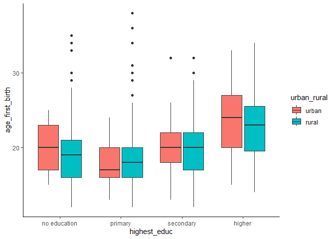

```r
ggplot(data = ir_clean,
   mapping = aes(x = highest_educ,
                 y = age_first_birth,
                 fill = urban_rural)) +
   geom_boxplot() +
   theme_classic()
```

As well as applying themes to one plot at a time, you can change the global default theme with `theme_set()`. For example, if you run `theme_set(theme_bw())` it will use a white background with grid lines for all plots.

```r
# Set global ggplot theme
theme_set(theme_bw())
```

Now when we run the same code again (without a `theme_*()` function), it will apply the theme we set above.

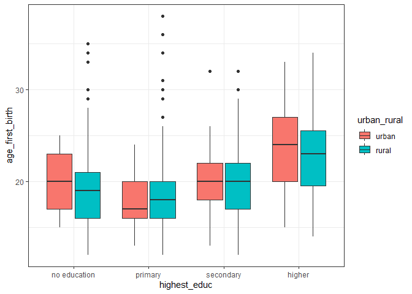

```r
ggplot(data = ir_clean,
   mapping = aes(x = highest_educ,
                 y = age_first_birth,
                 fill = urban_rural)) +
   geom_boxplot()
```

Any new plots will also be affected by `theme_set()`.

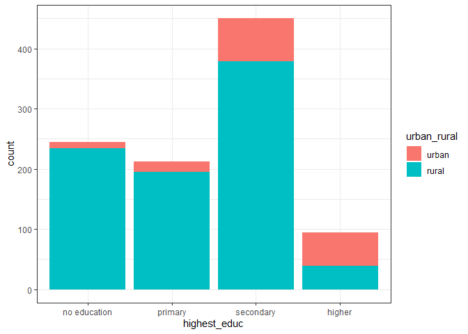

```r
ggplot(data = ir_clean,
  mapping = aes(
    x = highest_educ,
    fill = urban_rural)) +
  geom_bar()
```